# Analyzing Individual BGG Users

Phil Henrickson

2022-01-02

# **raaayden’s** BoardGameGeek Collection

This notebook contains a set of analyses for the selected user’s boardgamegeek collection. The bulk of the analysis is focused on building a user-specific predictive model to predict the games that raaayden is likely to own. This enables to ask questions like, based on the games the user currently owns, what games are a good fit for their collection? What upcoming games are they likely to purchase?

This analysis is based on data from BoardGameGeek that was last updated on **2021-12-20.**

# 1 Collection Overview

We can look at a basic description of the number of games that the user owns, has rated, has previously owned, etc.

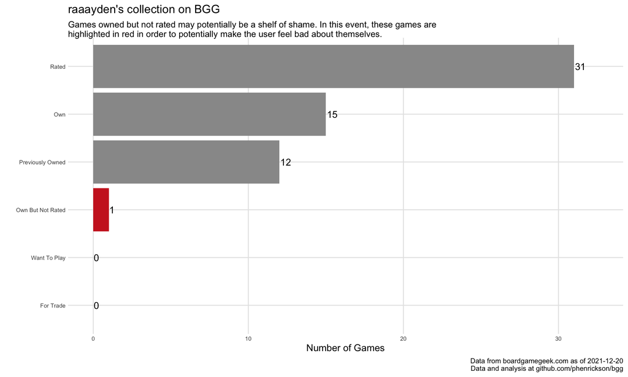

What years has the user owned/rated games from? While we can’t see when a user added or removed a game from their collection, we can look at their collection by the years in which their games were published.

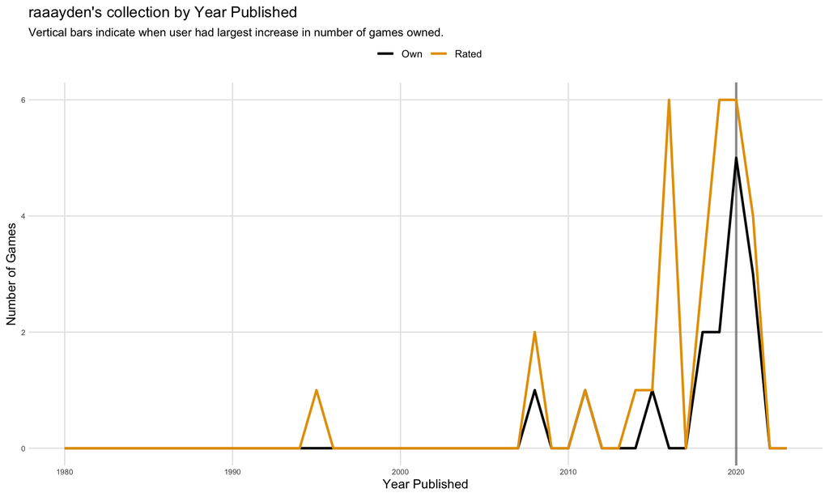

## 1.1 What types of games does raaayden own?

We can look at the most frequent types of categories, mechanics, designers, and artists that appear in a user’s collection.

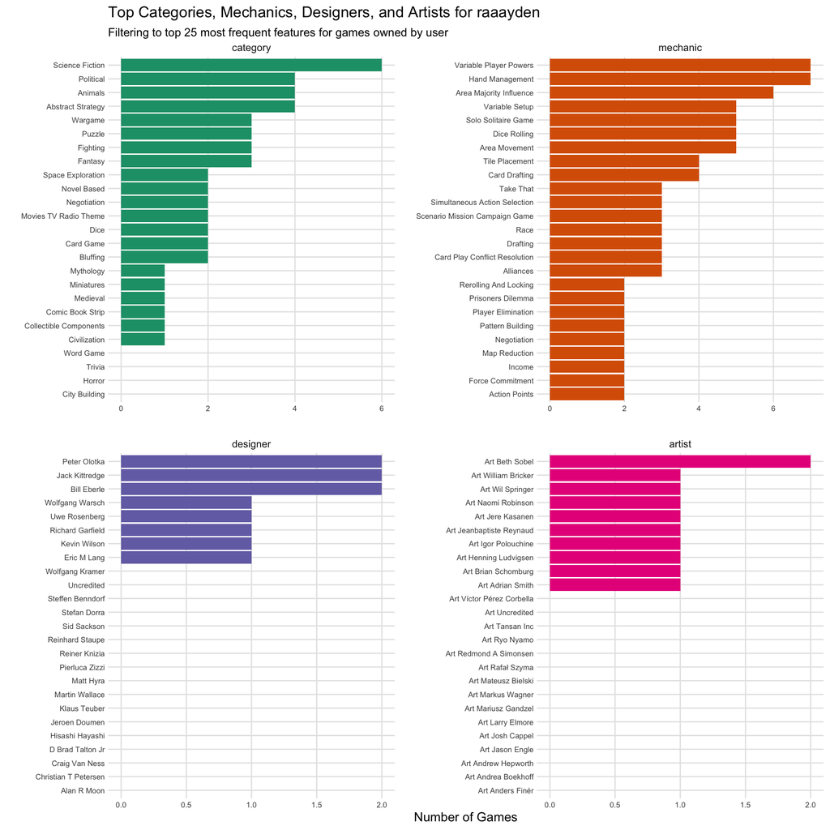

# 2 Modeling **raaayden’s** Collection

| username | dataset | period | games_owned | games_rated | games_played |
| --- | --- | --- | --- | --- | --- |
| raaayden | training | published before 2020 | 6 | 20 | 20 |
| raaayden | test | published 2020 or later | 8 | 10 | 11 |

There are two main (binary) outcomes we will be modeling for the user.

The first, **own** refers to whether the user currently lists a game as owned in their collection. The second, **played** refers to whether the user currently owns, has rated, or previously owned a game. This means the latter will generally have a larger list of games, but may still be a useful category to examine for people who play lots of games without necessarily owning them.

We will train predictive models to learn the probability that the user will own or play individual games based on their features.

## 2.1 Coefficients for raaayden

We can examine coefficients from the trained modes, which are penalized logistic regressions fit to our two main outcomes. Positive values indicate that a feature increases a user’s probabilility of owning/rating a game, while negative values indicate a feature decreases the probability.

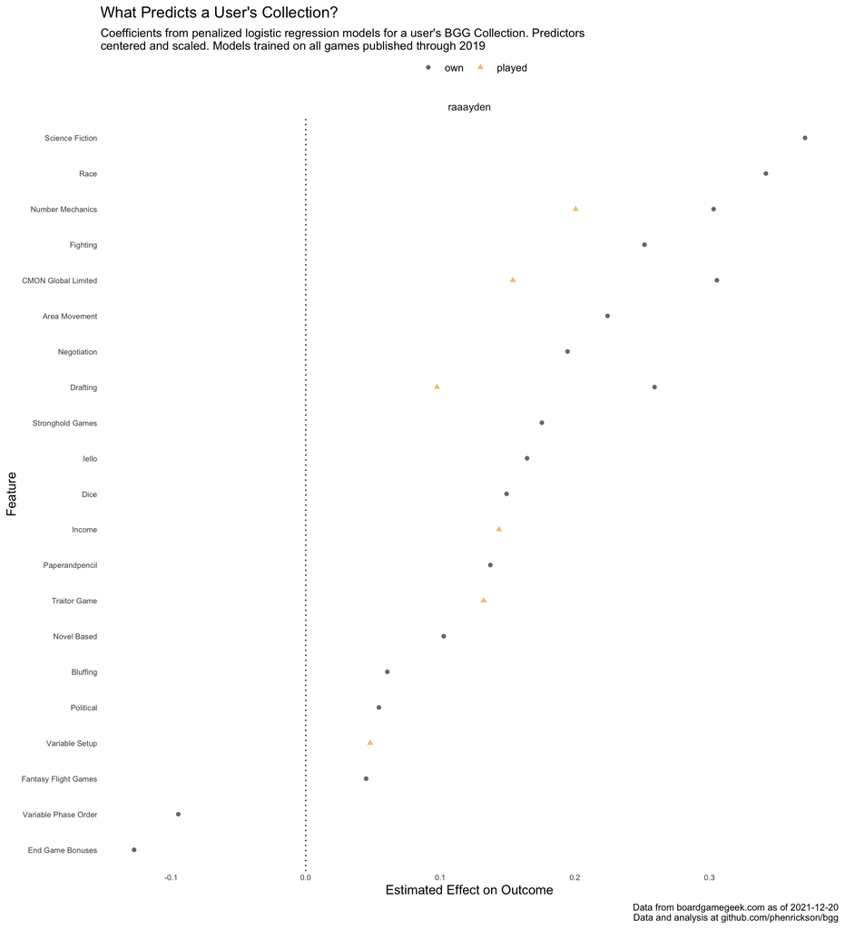

## 2.2 Visualizing Predictors for raaayden’s Collection

Why did the model identify these features? We can make density plots of the important features for predicting whether the user owned a game. Blue indicates the density for games owned by the user, while grey indicates the density for games not owned by the user.

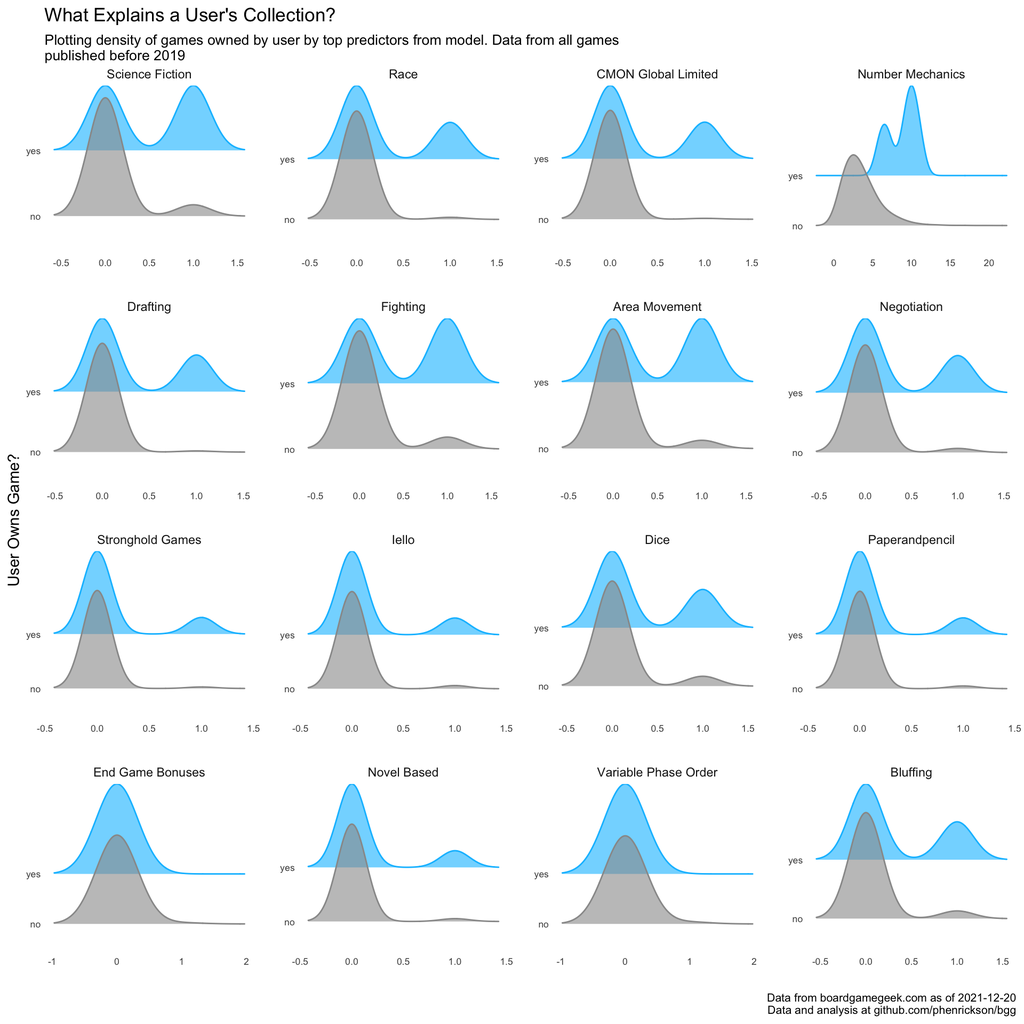

Binary predictors can be difficult to see with this visualization, so we can also directly examine the percentage of games in a user’s collection with a predictor vs the percentage of all games with that predictor.

| username | Feature | % of Games with Feature In_Collection | % of Games with Feature All_Games | Ratio |
| --- | --- | --- | --- | --- |
| raaayden | CMON Global Limited | 33.3% | 0.8% | 41.3 |
| raaayden | Drafting | 33.3% | 1.0% | 32.2 |
| raaayden | Race | 33.3% | 1.9% | 17.8 |
| raaayden | Stronghold Games | 16.7% | 1.5% | 11.1 |
| raaayden | Space Exploration | 16.7% | 1.7% | 9.9 |
| raaayden | Negotiation | 33.3% | 3.6% | 9.2 |
| raaayden | Area Movement | 50.0% | 6.4% | 7.8 |
| raaayden | Fantasy Flight Games | 16.7% | 2.7% | 6.3 |
| raaayden | Paperandpencil | 16.7% | 2.7% | 6.2 |
| raaayden | Novel Based | 16.7% | 2.8% | 5.9 |
| raaayden | Science Fiction | 50.0% | 8.7% | 5.7 |
| raaayden | Fighting | 50.0% | 9.1% | 5.5 |
| raaayden | Iello | 16.7% | 3.1% | 5.3 |
| raaayden | Political | 16.7% | 3.2% | 5.2 |
| raaayden | Trading | 16.7% | 3.2% | 5.2 |
| raaayden | Bluffing | 33.3% | 6.7% | 4.9 |
| raaayden | Area Majority Influence | 50.0% | 11.0% | 4.5 |
| raaayden | Movies TV Radio Theme | 16.7% | 3.9% | 4.2 |
| raaayden | Dice | 33.3% | 8.5% | 3.9 |
| raaayden | End Game Bonuses | 0.0% | 1.3% | 0.0 |
| raaayden | Variable Phase Order | 0.0% | 2.1% | 0.0 |
| raaayden | Modular Board | 0.0% | 10.9% | 0.0 |
| raaayden | Horror | 0.0% | 4.0% | 0.0 |
| raaayden | Word Game | 0.0% | 1.8% | 0.0 |
| raaayden | Trivia | 0.0% | 1.8% | 0.0 |

# 3 Assess Model’s Performance on Training Set

Before predicting games in upcoming years, we can examine how well the model did and what games it liked in the training set. In this case, we used resampling techniques (cross validation) to ensure that the model had not seen a game before making its predictions.

## 3.1 Separation Plot

An easy way to examine the performance of classification model is to view a separation plot. We plot the predicted probabilities from the model for every game (from resampling) from lowest to highest. We then overlay a blue line for any game that the user does own. A good classifier is one that is able to *separate* the blue (games owned by the user) from the white (games not owned by the user), with most of the blue occurring at the highest probabilities (right side of the chart).

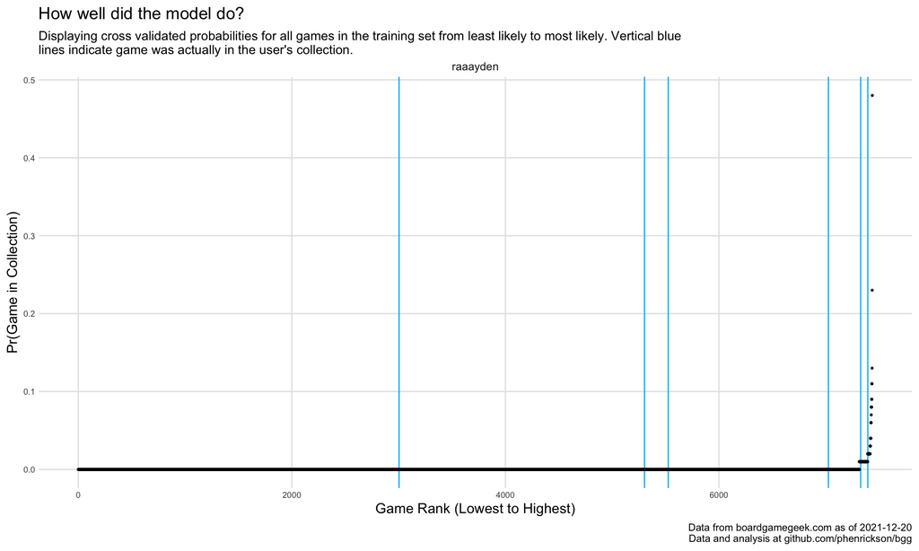

## 3.2 Top Games for **raaayden** from Training Set

We can display this information in table form, displaying the 100 games with the highest probability of ownership, adding a blue line when the user does own the game.

| username | yearpublished | game_id | name | pred_played | pred_own | actual_played | actual_own |
| --- | --- | --- | --- | --- | --- | --- | --- |
| raaayden | 2012 | 63628 | The Manhattan Project | 0.01 | 0.48 | 0 | 0 |
| raaayden | 2018 | 313010 | Cosmic Encounter: 42nd Anniversary Edition | 0.00 | 0.23 | 0 | 0 |
| raaayden | 1979 | 121 | Dune | 0.00 | 0.13 | 0 | 0 |
| raaayden | 2017 | 228341 | Pulsar 2849 | 0.01 | 0.11 | 0 | 0 |
| raaayden | 2019 | 256729 | Wacky Races: The Board Game | 0.03 | 0.11 | 0 | 0 |
| raaayden | 2017 | 221805 | Breaking Bad: The Board Game | 0.01 | 0.09 | 0 | 0 |
| raaayden | 2018 | 205896 | Rising Sun | 0.18 | 0.09 | 0 | 0 |
| raaayden | 2019 | 269210 | Twice as Clever! | 0.00 | 0.08 | 0 | 0 |
| raaayden | 2015 | 173486 | Dune: The Dice Game | 0.00 | 0.08 | 0 | 0 |
| raaayden | 2018 | 236457 | Architects of the West Kingdom | 0.11 | 0.08 | 0 | 0 |
| raaayden | 2018 | 244711 | Newton | 0.49 | 0.07 | 0 | 0 |
| raaayden | 2016 | 195528 | La Granja: No Siesta | 0.01 | 0.06 | 0 | 0 |
| raaayden | 2019 | 269199 | Dizzle | 0.00 | 0.06 | 0 | 0 |
| raaayden | 2018 | 245654 | Railroad Ink: Deep Blue Edition | 0.00 | 0.06 | 0 | 0 |
| raaayden | 2010 | 25292 | Merchants & Marauders | 0.00 | 0.04 | 0 | 0 |
| raaayden | 2014 | 146886 | La Granja | 0.07 | 0.04 | 0 | 0 |
| raaayden | 2016 | 167791 | Terraforming Mars | 0.01 | 0.04 | 1 | 0 |
| raaayden | 2015 | 171273 | FUSE | 0.01 | 0.04 | 0 | 0 |
| raaayden | 2016 | 192120 | Meeple War | 0.01 | 0.03 | 0 | 0 |
| raaayden | 2017 | 195539 | The Godfather: Corleone's Empire | 0.01 | 0.03 | 0 | 0 |
| raaayden | 2019 | 253185 | Chai | 0.01 | 0.03 | 0 | 0 |
| raaayden | 2016 | 155821 | Inis | 0.03 | 0.02 | 0 | 0 |
| raaayden | 2015 | 170216 | Blood Rage | 0.01 | 0.02 | 1 | 1 |
| raaayden | 2015 | 172381 | My Village | 0.00 | 0.02 | 0 | 0 |
| raaayden | 2015 | 179182 | Dojo Kun | 0.03 | 0.02 | 0 | 0 |
| raaayden | 2014 | 155068 | Arcadia Quest | 0.03 | 0.02 | 0 | 0 |
| raaayden | 2016 | 206540 | Banana Bandits | 0.01 | 0.02 | 0 | 0 |
| raaayden | 2006 | 21241 | Neuroshima Hex! 3.0 | 0.01 | 0.02 | 0 | 0 |
| raaayden | 2016 | 205046 | Capital Lux | 0.01 | 0.02 | 0 | 0 |
| raaayden | 2017 | 231280 | Harvest Dice | 0.01 | 0.02 | 0 | 0 |

[output cut: 70 more lines]

We can also more formally assess how well the model did in resampling by looking at the area under the receiver operating characteristic. A perfect model would receive a score of 1, while a model that cannot predict the outcome will default to a score of 0.5. The extent to which something is a *good* score depends on the setting, but generally anything in the .8 to .9 range is very good while the .7 to .8 range is perfectly acceptable.

| username | outcome_type | .metric | .estimator | .estimate |
| --- | --- | --- | --- | --- |
| raaayden | own | roc_auc | binary | 0.798 |
| raaayden | played | roc_auc | binary | 0.789 |

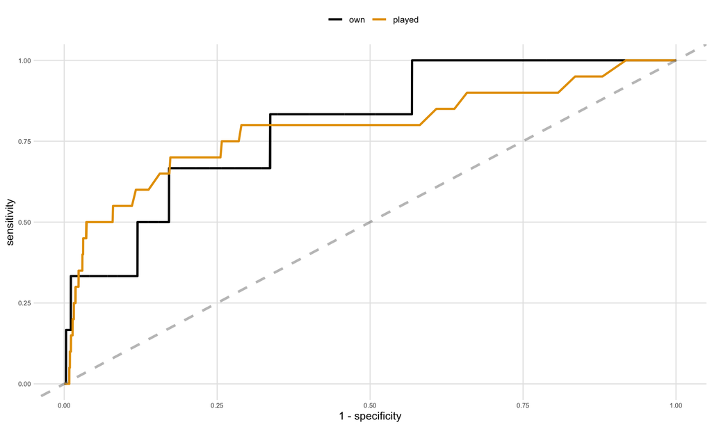

Another way to think about the model performance is to view its lift, or its ability to detect the positive outcomes over that of a null model. High lift indicates the model can much more quickly find all of the positive outcomes (in this case, games owned or played by the user), while a model with no lift is no better than random guessing.

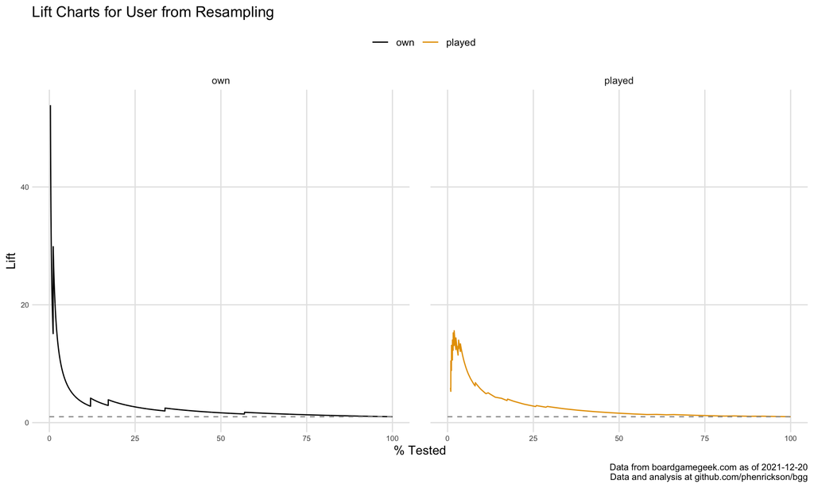

## 3.3 Most and Least Likely Games

What games does the model think raaayden is **most likely to own** that are **not** in their collection?

| username | yearpublished | game_id | name | pred_own | actual_own |
| --- | --- | --- | --- | --- | --- |
| raaayden | 2012 | 63628 | The Manhattan Project | 0.48 | 0 |
| raaayden | 2018 | 313010 | Cosmic Encounter: 42nd Anniversary Edition | 0.23 | 0 |
| raaayden | 1979 | 121 | Dune | 0.13 | 0 |
| raaayden | 2017 | 228341 | Pulsar 2849 | 0.11 | 0 |
| raaayden | 2019 | 256729 | Wacky Races: The Board Game | 0.11 | 0 |

What games does the model think raaayden is **least likely to own** that **are** in their collection?

| username | yearpublished | game_id | name | pred_own | actual_own |
| --- | --- | --- | --- | --- | --- |
| raaayden | 2018 | 244522 | That's Pretty Clever! | 0.00 | 1 |
| raaayden | 2011 | 70323 | King of Tokyo | 0.00 | 1 |
| raaayden | 2019 | 283355 | Dune | 0.00 | 1 |
| raaayden | 2008 | 39463 | Cosmic Encounter | 0.00 | 1 |
| raaayden | 2018 | 237182 | Root | 0.01 | 1 |

## 3.4 Top Games by Year

Top 25 games most likely to be owned by the user in each year, highlighting in blue the games that the user has owned/played.

| rank | 2011 | 2012 | 2013 | 2014 | 2015 | 2016 | 2017 | 2018 | 2019 |
| --- | --- | --- | --- | --- | --- | --- | --- | --- | --- |
| 1 | Gears of War: The Board Game | The Manhattan Project | City of Remnants | La Granja | Dune: The Dice Game | La Granja: No Siesta | Pulsar 2849 | Cosmic Encounter: 42nd Anniversary Edition | Wacky Races: The Board Game |
| 2 | Band of Brothers: Screaming Eagles | Rex: Final Days of an Empire | Firefly: The Game | Arcadia Quest | FUSE | Terraforming Mars | Breaking Bad: The Board Game | Rising Sun | Twice as Clever! |
| 3 | A Few Acres of Snow | Exodus: Proxima Centauri | Gearworld: The Borderlands | Patchwork | Blood Rage | Meeple War | The Godfather: Corleone's Empire | Architects of the West Kingdom | Dizzle |
| 4 | Sekigahara: The Unification of Japan | Neuroshima: Convoy | Patchistory | Star Realms | My Village | Inis | Harvest Dice | Newton | Chai |
| 5 | Fighting Formations: Grossdeutschland Motorized Infantry Division | Star Trek Deck Building Game: The Next Generation – Next Phase | Tomorrow | The Captain Is Dead | Dojo Kun | Banana Bandits | Richard the Lionheart | Railroad Ink: Deep Blue Edition | Zombicide: Dark Side |
| 6 | No Retreat! The Russian Front | Spartacus: A Game of Blood and Treachery | Impulse | Star Wars: Imperial Assault | 504 | Capital Lux | Sagrada | Forum Trajanum | HATE |
| 7 | Nightfighter | Seasons | Dungeon Command: Blood of Gruumsh | Fallen | Steampunk Rally | The Dragon & Flagon | Dragon Castle | Airship City | Unmatched: Robin Hood vs. Bigfoot |
| 8 | Space Infantry | Robinson Crusoe: Adventures on the Cursed Island | Band of Brothers: Ghost Panzer | Holdfast: Russia 1941-42 | Between Two Cities | Roll Player | Gekido: Bot Battles | A Song of Ice & Fire: Tabletop Miniatures Game – Stark vs Lannister Starter Set | Western Empires |
| 9 | No Peace Without Spain!: The War of the Spanish Succession 1702-1713 | Zombicide | BattleLore: Second Edition | Heroes of Normandie | Zombicide: Black Plague | Flamme Rouge | Pocket Mars | Root | Yukon Airways |
| 10 | FAB: Sicily | Kings of War | No Retreat!: The North African Front | Strife: Legacy of the Eternals | Coffee Roaster | Cry Havoc | Arcadia Quest: Inferno | Star Realms: Frontiers | Aquatica |
| 11 | Revolver | Mage Wars Arena | Crusade and Revolution: The Spanish Civil War, 1936-1939 | Star Wars: Empire vs. Rebellion | Survive: Space Attack! | Agricola (Revised Edition) | Muse | The Grizzled: Armistice Edition | Nova Luna |
| 12 | 1955: The War of Espionage | Dungeon Command: Sting of Lolth | Sedition Wars: Battle for Alabaster | Fleet Commander: 1 – Ignition | Best Treehouse Ever | Star Trek: Ascendancy | Ethnos | Cosmic Run: Regeneration | Machina Arcana (Second/Third Edition) |
| 13 | Test of Fire: Bull Run 1861 | Dungeon Command: Heart of Cormyr | Dungeon Twister: The Card Game | Jäger und Späher | Raid & Trade | Junk Art | Twilight Imperium: Fourth Edition | Planet | Unmatched: Battle of Legends, Volume One |
| 14 | Steam Torpedo: First Contact | Dungeon Command: Curse of Undeath | Invaders | Space Hulk (Fourth Edition) | The Grizzled | Old School Tactical: Volume 1 – Fighting on the Eastern Front 1941/42 | Masmorra: Dungeons of Arcadia | Railroad Ink: Blazing Red Edition | Herbaceous Sprouts |
| 15 | Yomi | DreadBall: The Futuristic Sports Game | Risk: Plants vs. Zombies | Wir sind das Volk! | Stronghold: 2nd edition | Silent Victory: U.S. Submarines in the Pacific, 1941-45 | Michael Strogoff | Roll to the Top! | Trismegistus: The Ultimate Formula |
| 16 | Laser Chess | Kingdom of Heaven: The Crusader States 1097-1291 | Metallum | The Battle of Five Armies | Wing Leader: Victories 1940-1942 | Wing Leader: Supremacy 1943-1945 | Unfair | Kodama Duo | Amul |
| 17 | Omen: A Reign of War | Celles: The Ardennes, December 23-27, 1944 | France '40 | Ortus Regni | Warhammer Age of Sigmar | MBT (Second Edition) | Paper Tales | Gettysburg | Fast Sloths |
| 18 | Ascension: Return of the Fallen | Antike Duellum | Castellan | Smash Up: Science Fiction Double Feature | The U.S. Civil War | Smash Up: It's Your Fault! | Journal 29: Interactive Book Game | Star Wars: Legion | Claustrophobia 1643 |
| 19 | Drako: Dragon & Dwarves | Targi | Island Siege | Pagoda | Guild Ball | Heir to the Pharaoh | Techno Bowl: Arcade Football Unplugged | Too Many Bones: Undertow | The Last Hundred Yards |
| 20 | Kulami | Game of Thrones: The Card Game | Smash Up: Awesome Level 9000 | Akrotiri | BattleCON: Fate of Indines | Deathwatch: Overkill | Commands & Colors Tricorne: The American Revolution | Nightfighter Ace: Air Defense Over Germany, 1943-44 | Nevsky: Teutons and Rus in Collision 1240-1242 |
| 21 | Hemloch | For the Crown (Second Edition) | Pixel Tactics 2 | Smash Up: Monster Smash | The Great War | Mini Rogue: A 9-Card Print-and-Play Game | Runewars Miniatures Game | 1066, Tears to Many Mothers | Hearts and Minds: Vietnam 1965-1975 (Third Edition) |
| 22 | Infidel | 1989: Dawn of Freedom | Smash Up: The Obligatory Cthulhu Set | Consentacle | The Horus Heresy: Betrayal at Calth | Guild Ball: Kick Off! | Aristeia! | Skies Above the Reich | War of the Worlds: The New Wave |
| 23 | Advanced Squad Leader: Starter Kit Expansion Pack #1 | Mr. Madison's War: The Incredible War of 1812 | The Ravens of Thri Sahashri | Draco Magi | ...and then, we held hands. | Tokyo Highway | Fields of Despair: France 1914-1918 | Crystal Clans | Harry Potter: Hogwarts Battle – Defence Against the Dark Arts |
| 24 | Carnac | Nuklear Winter '68 | The Dark Valley | Adventure Time Card Wars: Finn vs. Jake | Smash Up: Pretty Pretty Smash Up | 13 Days: The Cuban Missile Crisis | Enemy Coast Ahead: The Doolittle Raid | Dual Powers: Revolution 1917 | Revolution of 1828 |
| 25 | Battle of LITS | Revolver 2: Last Stand at Malpaso | Batman: Arkham City Escape | Lords of War: Templars versus Undead | Pixel Tactics 4 | One Deck Dungeon | 13 Minutes: The Cuban Missile Crisis, 1962 | Blitz Bowl | Undaunted: Normandy |

## 3.5 Interactive Predictions from Resampling

Interactive table for predictions from resampling.

|  | username | yearpublished | rank | game_id | name | pred_played | pred_own | actual_played | actual_own |
| --- | --- | --- | --- | --- | --- | --- | --- | --- | --- |
| 1 | raaayden | 1900 | 105 | 2136 | Pachisi | 0 | 0.01 | 0 | 0 |
| 2 | raaayden | 1900 | 137 | 5546 | Marbles | 0 | 0 | 0 | 0 |
| 3 | raaayden | 1900 | 140 | 11901 | Tic-Tac-Toe | 0 | 0 | 0 | 0 |
| 4 | raaayden | 1900 | 190 | 188 | Go | 0 | 0 | 0 | 0 |
| 5 | raaayden | 1900 | 305 | 171 | Chess | 0 | 0 | 0 | 0 |
| 6 | raaayden | 1900 | 316 | 2065 | Shogi | 0 | 0 | 0 | 0 |
| 7 | raaayden | 1900 | 318 | 2393 | Xiangqi | 0 | 0 | 0 | 0 |
| 8 | raaayden | 1900 | 561 | 26952 | International Checkers | 0 | 0 | 0 | 0 |
| 9 | raaayden | 1900 | 597 | 1602 | The Royal Game of Ur | 0 | 0 | 0 | 0 |
| 10 | raaayden | 1900 | 598 | 2083 | Checkers | 0 | 0 | 0 | 0 |

[output cut: 7426 more lines]

# 4 Validating the Model on 2020

How well did a model trained on a user’s collection through 2019 perform in predicting games for the user from 2020?

| username | outcome_type | yearpublished | .metric | .estimator | .estimate |
| --- | --- | --- | --- | --- | --- |
| raaayden | own | 2020 | roc_auc | binary | 0.771 |
| raaayden | played | 2020 | roc_auc | binary | 0.881 |

Table of top 25 games from 2020, highlighting games that the user owns.

| username | yearpublished | game_id | name | pred_own | pred_played | actual_own | actual_played |
| --- | --- | --- | --- | --- | --- | --- | --- |
| raaayden | 2020 | 297030 | Tekhenu: Obelisk of the Sun | 0.11 | 0.22 | 0 | 0 |
| raaayden | 2020 | 256999 | Project: ELITE | 0.05 | 0.02 | 0 | 0 |
| raaayden | 2020 | 257193 | Starcadia Quest | 0.03 | 0.01 | 0 | 0 |
| raaayden | 2020 | 298638 | Sheriff of Nottingham (2nd Edition) | 0.03 | 0.01 | 0 | 0 |
| raaayden | 2020 | 317105 | Tiny Epic Galaxies BLAST OFF! | 0.02 | 0.00 | 0 | 0 |
| raaayden | 2020 | 184267 | On Mars | 0.01 | 0.08 | 0 | 0 |
| raaayden | 2020 | 246900 | Eclipse: Second Dawn for the Galaxy | 0.01 | 0.03 | 1 | 1 |
| raaayden | 2020 | 267009 | Rome & Roll | 0.01 | 0.01 | 0 | 0 |
| raaayden | 2020 | 274450 | Last Aurora | 0.01 | 0.00 | 0 | 0 |
| raaayden | 2020 | 294484 | Unmatched: Cobble & Fog | 0.01 | 0.00 | 0 | 0 |
| raaayden | 2020 | 298047 | Marvel United | 0.01 | 0.01 | 0 | 0 |
| raaayden | 2020 | 298572 | Cosmic Encounter Duel | 0.01 | 0.00 | 0 | 0 |
| raaayden | 2020 | 299191 | Migration: Mars | 0.01 | 0.00 | 0 | 0 |
| raaayden | 2020 | 301880 | Raiders of Scythia | 0.01 | 0.02 | 0 | 0 |
| raaayden | 2020 | 302465 | Obsidia | 0.01 | 0.01 | 0 | 0 |
| raaayden | 2020 | 306481 | Tawantinsuyu: The Inca Empire | 0.01 | 0.03 | 0 | 0 |
| raaayden | 2020 | 306735 | Under Falling Skies | 0.01 | 0.01 | 0 | 0 |
| raaayden | 2020 | 317231 | Monasterium | 0.01 | 0.01 | 0 | 0 |
| raaayden | 2020 | 318553 | Rajas of the Ganges: The Dice Charmers | 0.01 | 0.00 | 0 | 0 |
| raaayden | 2020 | 325635 | Unmatched: Little Red Riding Hood vs. Beowulf | 0.01 | 0.00 | 0 | 0 |
| raaayden | 2020 | 147635 | Dungeon Crusade: Book I – Genesis of Evil | 0.00 | 0.00 | 0 | 0 |
| raaayden | 2020 | 174400 | BattleCON: Wanderers of Indines | 0.00 | 0.00 | 0 | 0 |
| raaayden | 2020 | 174959 | The First Jihad: The Rise of Islam 632-750 | 0.00 | 0.00 | 0 | 0 |
| raaayden | 2020 | 177014 | Giga-Robo! | 0.00 | 0.00 | 0 | 0 |
| raaayden | 2020 | 177096 | Freedom! | 0.00 | 0.00 | 0 | 0 |

# 5 Predicting Upcoming Games (2020 and On) for **raaayden**

Examine the top games for the test set.

| username | yearpublished | game_id | name | rank | own | played |
| --- | --- | --- | --- | --- | --- | --- |
| raaayden | 2020 | 297030 | Tekhenu: Obelisk of the Sun | 1 | 0.11 | 0.22 |
| raaayden | 2020 | 256999 | Project: ELITE | 2 | 0.05 | 0.02 |
| raaayden | 2020 | 257193 | Starcadia Quest | 3 | 0.03 | 0.01 |
| raaayden | 2020 | 298638 | Sheriff of Nottingham (2nd Edition) | 4 | 0.03 | 0.01 |
| raaayden | 2020 | 317105 | Tiny Epic Galaxies BLAST OFF! | 5 | 0.02 | 0.00 |
| raaayden | 2020 | 306735 | Under Falling Skies | 6 | 0.01 | 0.01 |
| raaayden | 2020 | 274450 | Last Aurora | 7 | 0.01 | 0.00 |
| raaayden | 2020 | 246900 | Eclipse: Second Dawn for the Galaxy | 8 | 0.01 | 0.03 |
| raaayden | 2020 | 301880 | Raiders of Scythia | 9 | 0.01 | 0.02 |
| raaayden | 2020 | 318553 | Rajas of the Ganges: The Dice Charmers | 10 | 0.01 | 0.00 |
| raaayden | 2020 | 184267 | On Mars | 11 | 0.01 | 0.08 |
| raaayden | 2020 | 325635 | Unmatched: Little Red Riding Hood vs. Beowulf | 12 | 0.01 | 0.00 |
| raaayden | 2020 | 302465 | Obsidia | 13 | 0.01 | 0.01 |
| raaayden | 2020 | 294484 | Unmatched: Cobble & Fog | 14 | 0.01 | 0.00 |
| raaayden | 2020 | 267009 | Rome & Roll | 15 | 0.01 | 0.01 |
| raaayden | 2020 | 299191 | Migration: Mars | 16 | 0.01 | 0.00 |
| raaayden | 2020 | 306481 | Tawantinsuyu: The Inca Empire | 17 | 0.01 | 0.03 |
| raaayden | 2020 | 317231 | Monasterium | 18 | 0.01 | 0.01 |
| raaayden | 2020 | 298047 | Marvel United | 19 | 0.01 | 0.01 |
| raaayden | 2020 | 298572 | Cosmic Encounter Duel | 20 | 0.01 | 0.00 |
| raaayden | 2020 | 296557 | Zen Garden | 21 | 0.00 | 0.00 |
| raaayden | 2020 | 300081 | Hideous Abomination | 22 | 0.00 | 0.00 |
| raaayden | 2020 | 291874 | Dwergar | 23 | 0.00 | 0.00 |
| raaayden | 2020 | 254888 | High Rise | 24 | 0.00 | 0.00 |
| raaayden | 2020 | 279537 | The Search for Planet X | 25 | 0.00 | 0.00 |
| raaayden | 2021 | 291859 | Riftforce | 1 | 0.19 | 0.01 |
| raaayden | 2021 | 285967 | Ankh: Gods of Egypt | 2 | 0.14 | 0.02 |
| raaayden | 2021 | 322588 | Origins: First Builders | 3 | 0.10 | 0.05 |
| raaayden | 2021 | 316786 | Tabannusi: Builders of Ur | 4 | 0.07 | 0.04 |
| raaayden | 2021 | 309250 | Empyrean Hero: The Card Game | 5 | 0.06 | 0.01 |
| raaayden | 2021 | 344408 | Full Throttle! | 6 | 0.03 | 0.01 |
| raaayden | 2021 | 298229 | Steampunk Rally Fusion | 7 | 0.02 | 0.00 |
| raaayden | 2021 | 339789 | Welcome to the Moon | 8 | 0.02 | 0.00 |
| raaayden | 2021 | 308566 | Nova Lux | 9 | 0.02 | 0.00 |
| raaayden | 2021 | 291828 | Car Wars (Sixth Edition) | 10 | 0.02 | 0.00 |
| raaayden | 2021 | 291847 | Mantis Falls | 11 | 0.01 | 0.07 |
| raaayden | 2021 | 320960 | Roll In One | 12 | 0.01 | 0.00 |
| raaayden | 2021 | 286751 | Zombicide: 2nd Edition | 13 | 0.01 | 0.01 |
| raaayden | 2021 | 335541 | We Care: a Grizzled Game | 14 | 0.01 | 0.01 |
| raaayden | 2021 | 343847 | Dustbiters | 15 | 0.01 | 0.00 |
| raaayden | 2021 | 324242 | Sheepy Time | 16 | 0.01 | 0.00 |
| raaayden | 2021 | 299684 | Khôra: Rise of an Empire | 17 | 0.01 | 0.01 |
| raaayden | 2021 | 252752 | Genotype: A Mendelian Genetics Game | 18 | 0.01 | 0.01 |
| raaayden | 2021 | 273330 | Bloodborne: The Board Game | 19 | 0.01 | 0.02 |
| raaayden | 2021 | 200511 | After The Empire | 20 | 0.01 | 0.01 |
| raaayden | 2021 | 332420 | NEXUM: Galaxy | 21 | 0.01 | 0.00 |
| raaayden | 2021 | 333553 | For the King (and Me) | 22 | 0.01 | 0.01 |
| raaayden | 2021 | 318084 | Furnace | 23 | 0.01 | 0.02 |
| raaayden | 2021 | 304783 | Hadrian's Wall | 24 | 0.01 | 0.01 |
| raaayden | 2021 | 301441 | Drawn to Adventure | 25 | 0.01 | 0.01 |
| raaayden | 2022 | 299594 | Megapulse | 1 | 0.03 | 0.00 |
| raaayden | 2022 | 331106 | The Witcher: Old World | 2 | 0.03 | 0.01 |
| raaayden | 2022 | 282775 | The Warp | 3 | 0.01 | 0.00 |
| raaayden | 2022 | 321608 | Hegemony: Lead Your Class to Victory | 4 | 0.01 | 0.01 |
| raaayden | 2022 | 315610 | Massive Darkness 2: Hellscape | 5 | 0.01 | 0.01 |
| raaayden | 2022 | 336986 | Flamecraft | 6 | 0.00 | 0.00 |
| raaayden | 2022 | 280726 | Legacies | 7 | 0.00 | 0.00 |
| raaayden | 2022 | 326945 | Castles of Mad King Ludwig: Collector's Edition | 8 | 0.00 | 0.00 |
| raaayden | 2022 | 335427 | Wild: Serengeti | 9 | 0.00 | 0.00 |
| raaayden | 2022 | 324090 | Scarface 1920 | 10 | 0.00 | 0.00 |
| raaayden | 2022 | 305096 | Endless Winter: Paleoamericans | 11 | 0.00 | 0.00 |
| raaayden | 2022 | 319807 | Shogun no Katana | 12 | 0.00 | 0.00 |
| raaayden | 2022 | 274056 | HEL: The Last Saga | 13 | 0.00 | 0.00 |
| raaayden | 2022 | 266592 | TacTiki | 14 | 0.00 | 0.00 |
| raaayden | 2022 | 328866 | My Father's Work | 15 | 0.00 | 0.00 |
| raaayden | 2022 | 330973 | Volfyirion Guilds | 16 | 0.00 | 0.00 |
| raaayden | 2022 | 293941 | Mage Noir | 17 | 0.00 | 0.00 |
| raaayden | 2022 | 312512 | The Transcontinental | 18 | 0.00 | 0.00 |
| raaayden | 2022 | 342894 | Mythic Mischief | 19 | 0.00 | 0.00 |
| raaayden | 2022 | 318450 | Bios: Mesofauna | 20 | 0.00 | 0.00 |
| raaayden | 2022 | 322354 | DEFCON 1 | 21 | 0.00 | 0.00 |
| raaayden | 2022 | 237179 | Weather Machine | 22 | 0.00 | 0.00 |
| raaayden | 2022 | 270871 | Agemonia | 23 | 0.00 | 0.00 |
| raaayden | 2022 | 275215 | Namiji | 24 | 0.00 | 0.00 |
| raaayden | 2022 | 339592 | Sheep in Disguise | 25 | 0.00 | 0.00 |

## 5.1 Interactive Table for Upcoming Games 2020 and On

|  | username | yearpublished | game_id | name | rank | own | played |
| --- | --- | --- | --- | --- | --- | --- | --- |
| 1 | raaayden | 2021 | 291859 | Riftforce | 1 | 0.19 | 0.01 |
| 2 | raaayden | 2021 | 285967 | Ankh: Gods of Egypt | 2 | 0.14 | 0.02 |
| 3 | raaayden | 2020 | 297030 | Tekhenu: Obelisk of the Sun | 3 | 0.11 | 0.22 |
| 4 | raaayden | 2021 | 322588 | Origins: First Builders | 4 | 0.1 | 0.05 |
| 5 | raaayden | 2021 | 316786 | Tabannusi: Builders of Ur | 5 | 0.07 | 0.04 |
| 6 | raaayden | 2021 | 309250 | Empyrean Hero: The Card Game | 6 | 0.06 | 0.01 |
| 7 | raaayden | 2020 | 256999 | Project: ELITE | 7 | 0.05 | 0.02 |
| 8 | raaayden | 2021 | 344408 | Full Throttle! | 8 | 0.03 | 0.01 |
| 9 | raaayden | 2022 | 299594 | Megapulse | 9 | 0.03 | 0 |
| 10 | raaayden | 2020 | 257193 | Starcadia Quest | 10 | 0.03 | 0.01 |

[output cut: 1627 more lines]